# Assignment #2: Statistical analysis of thermal comfort research

- Show All Code
- Hide All Code
- View Source

Arch 241 - Fall 2026

Author

Urwa Irfan

Published

September 26, 2026

## Setup

```r
library(tidyverse) # dplyr and related packages
library(ggplot2) # plotting
library(gt) # printing tables
library(ggh4x) # plotting customisation
library(patchwork) # combining plots
library(ggcorrplot) # correlation matrix
library(rstatix) # statistical analysis
library(Metrics) # statistical analysis
library(car) # statistical analysis
```

```r
theme_set(theme_light(base_size = 10))
theme_update(
  strip.background = element_rect(fill = "#F5F5F5", color = "grey"),
  strip.text = element_text(color = "black"),
  strip.text.y = element_text(angle = 90)
)
theme_update(panel.grid = element_line(linetype = "dotted"))
cal_palette2 <- c("#3B7EA1", "#C4820E")
cal_palette3 = c("#3b7ea1", "#b0750c", "#003262")
cal_palette4 <- c("#003262", "#b0750c", "#3b7ea1", "#fdb515")
cal_palette5 <- c("#003262", "#b0750c", "#3b7ea1", "#fdb515", "#D9661F")
load_palette = c("#010090", "#8f0300")
```

```r
load("data/arch241a2.rda")
d <- arch241a2
dat = tibble(d) |>
   rename(T_op = Top) |> # for clarity
   mutate(Subject = factor(Subject, levels = as.character(sort(as.numeric(levels(Subject)))))) |> # relevel so it's sorted numerically, but kept as character for plotting
   filter(Experiment != "P") # because this was not a real test condition
```

## 1. Statistical summary of all variables

```r
summarize_variable = function(df, variable) {
   df |>
      # select(.data[[variable]]) |>
      summarise(
         Minimum = min(.data[[variable]]),
         `25th Quartile` = quantile(.data[[variable]], 0.25),
         Median = median(.data[[variable]]),
         `75th Quartile` = quantile(.data[[variable]], 0.75),
         Maximum = max(.data[[variable]]),
         Mean = mean(.data[[variable]]),
         `Standard Deviation` = sd(.data[[variable]])
      ) |>
      mutate(variable = variable)
}

summary_results = tibble()
variables = names(dat)[5:9]

for (var in variables) {
   summary_results = rbind(summary_results, summarize_variable(dat, var))
}
tbl_q1 = summary_results |>
   relocate(variable) |>
   mutate(variable = case_when(
      variable == "TS" ~ "Thermal Sensation (TS)",
      variable == "TC" ~ "Thermal Comfort (TC)",
      variable == "TA" ~ "Thermal Acceptability (TA)",
      variable == "PMV" ~ "Predicted Mean Vote (PMV)",
      variable == "PPD" ~ "Percentage People Dissatisfied (PPD)",
   )) |>
   gt(rowname_col = "variable") |>
   fmt_number()

tbl_q1
gtsave(tbl_q1, "output/q1_statistical-summary.html")
```

Table 1: Statistical summary

|  | Minimum | 25th Quartile | Median | 75th Quartile | Maximum | Mean | Standard Deviation |
| --- | --- | --- | --- | --- | --- | --- | --- |
| Thermal Sensation (TS) | −3.44 | −0.87 | 0.31 | 1.37 | 3.66 | 0.24 | 1.48 |
| Thermal Comfort (TC) | 1.05 | 1.75 | 2.06 | 2.66 | 3.73 | 2.18 | 0.63 |
| Thermal Acceptability (TA) | −0.88 | −0.15 | 0.15 | 0.54 | 0.98 | 0.16 | 0.46 |
| Predicted Mean Vote (PMV) | −1.90 | −0.90 | 1.30 | 2.30 | 2.60 | 0.78 | 1.65 |
| Percentage People Dissatisfied (PPD) | 24.00 | 35.00 | 61.50 | 88.00 | 94.00 | 60.67 | 27.18 |

**Interpretation.** For this question, I excluded the independent and categorical variables (T_op, RH, Sex, Subject, Experiment), because I don’t think a statistical analysis of these alone provides any insights about the research. The PMV and PPD were directly calculated from the independent variables, so their distribution is also not particularly helpful.

For the measured data collected (thermal acceptability, comfort, and sensation), we see a broad distribution within their ranges, with the mimimum/maximum values close to the extremes on the scales. The mean and median values are similar to each other (indicating the data may be normally distributed). The mean/median for TS and TA fall near the ‘neutral’ condition of 0, but the mean/median for TC is around 2 (slightly uncomfortable). This is an interesting incongruence in the data: if only the mean for TS/TA was near 0, I would guess that most occupants were always uncomfortably cold or hot with an even spread averaging out to 0. However, since the median is also near 0, perhaps it’s due to the nature of the survey design and how occupants interact with the questions.

## 2. Histograms of TC and TS

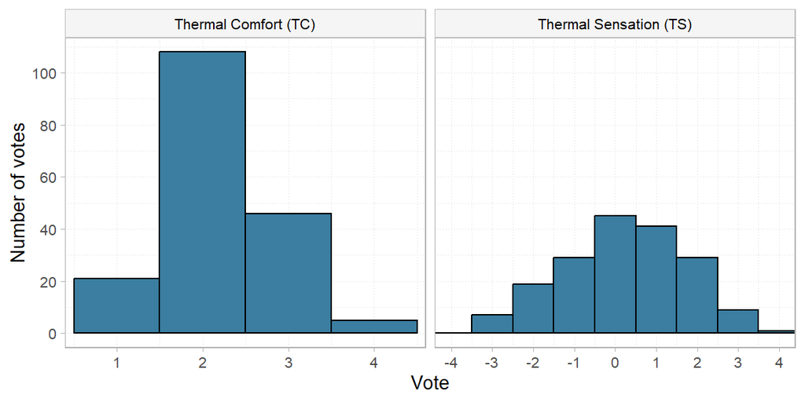

Figure 1: Histograms

```r
plt_q2 = dat |>
   select(TC, TS) |>
   pivot_longer(cols = c(TC, TS), names_to = "variable", values_to = "value") |>
   mutate(variable = case_when(
      variable == "TS" ~ "Thermal Sensation (TS)",
      variable == "TC" ~ "Thermal Comfort (TC)")
   ) |>
   ggplot(aes(value)) +
      geom_histogram(binwidth = 1, color = "black", fill = cal_palette2[1]) +
      labs(x = "Vote", y = "Number of votes") +
      scale_y_continuous(breaks = seq(0, 120, 20)) +
      facet_wrap(~ variable, scales = "free_x") +
      facetted_pos_scales(
         x = list(
            scale_x_continuous(limits = c(1, 4), expand = expansion(mult=0.2)),
            scale_x_continuous(limits = c(-4, 4), breaks = seq(-4, 4, 1))
         )
      )

plt_q2
ggsave("output/q2_histograms.png", width = 6, height = 3, units = "in")
```

**Interpretation.** While data for TC and TS were collected on a continuous scale, I have simplified the bins on the histograms to single vote counts for clearer interpretation. The histograms help clarify the previous summary: TS does look mostly normally distributed, but TC is skewed toward lower values. The TS data also largely agrees with the TC data: most people did not experience extreme thermal sensations (±3/4 bars are small) and thus were not extremely uncomfortable.

## 3. Boxplots of TS vs Sex, Subject and Experiment

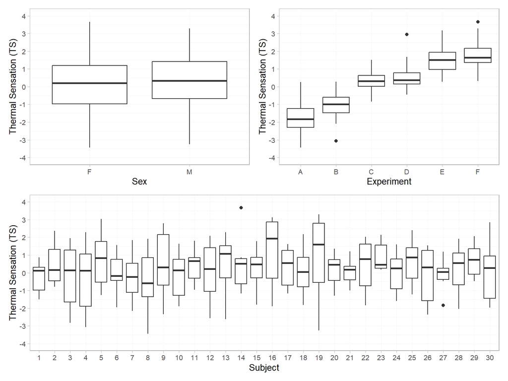

Figure 2: Box plots

```r
q3_boxplot = function(df, var) {
   df |>
   ggplot(aes(.data[[var]], TS)) +
      geom_boxplot() +
      labs(y = "Thermal Sensation (TS)") +
      scale_y_continuous(breaks = seq(-4, 4, 1), limits = c(-4, 4))
}

plt_q3_sex = q3_boxplot(dat, "Sex")
plt_q3_subject = q3_boxplot(dat, "Subject")
plt_q3_experiment = q3_boxplot(dat, "Experiment")
plt_q3 = (plt_q3_sex + plt_q3_experiment) / plt_q3_subject

plt_q3
ggsave("output/q3_boxplots.png", width = 8, height = 6, units = "in")
```

## 4. Correlation matrix

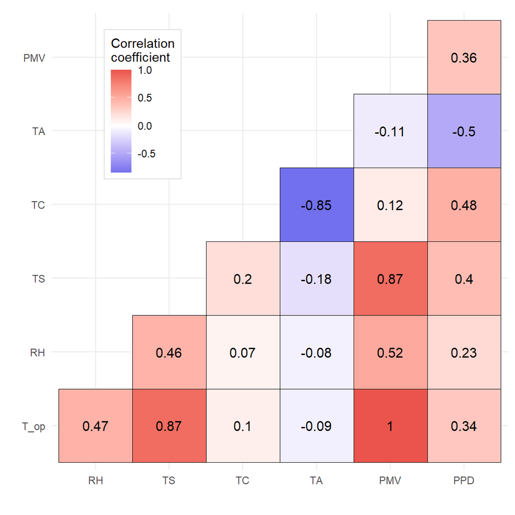

Figure 3: Correlation matrix

```r
# Variables: PMV, PPD, RH, TA, TC, TS, Top.
plt_q4 = dat |>
   select(T_op, RH, TS, TC, TA, PMV, PPD) |>
   cor() |>
   ggcorrplot(type = "lower", outline.color = "black", lab = TRUE) +
      labs(x = "", y = "", fill = "Correlation\ncoefficient") +
      scale_fill_gradient2(low = "#4c59ea", high = "#ea544c") +
      theme_minimal() +
      theme(legend.position = "inside", legend.position.inside = c(0.2, 0.8), legend.background = element_rect(colour = "#e0e0e0"),
         axis.text.x = element_text(angle = 0))

plt_q4
ggsave("output/q4_correlation-matrix.png", width = 6, height = 6, units = "in")
```

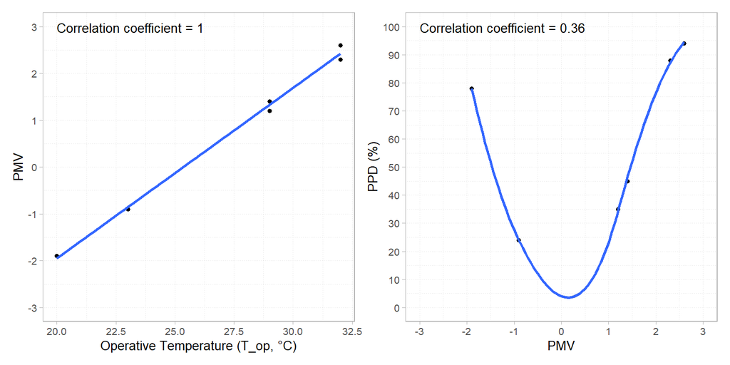

Figure 4: Correlation matrix - additional

```r
plt_q4_strong = dat |>
   ggplot(aes(T_op, PMV)) +
      geom_point() +
      geom_smooth(method = "lm") +
      labs(x = "Operative Temperature (T_op, °C)", y = "PMV") +
      annotate("text", x = 20, y = Inf, hjust = 0, vjust = 2, label = "Correlation coefficient = 1") +
      scale_y_continuous(breaks = seq(-3, 3, 1), limits = c(-3, 3))

plt_q4_weak = dat |>
   ggplot(aes(PMV, PPD)) +
      geom_point() +
      geom_smooth() +
      labs(x = "PMV", y = "PPD (%)") +
      annotate("text", x = -3, y = Inf, hjust = 0, vjust = 2, label = "Correlation coefficient = 0.36") +
      scale_x_continuous(breaks = seq(-3, 3, 1), limits = c(-3, 3)) +
      scale_y_continuous(breaks = seq(0, 100, 10), limits = c(0, 100))

plt_q4_addl = plt_q4_strong + plt_q4_weak
ggsave("output/q4_correlation-additional.png", width = 8, height = 4, units = "in")
plt_q4_addl
```

## 5. Normality of TC and TS

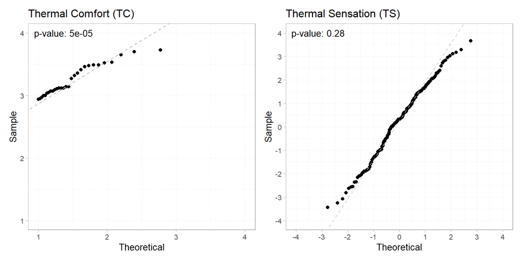

Figure 5: Normality

```r
q5_qqplot = function(df, var, varlabel, axlim) {
   p_val = shapiro.test(df[[var]])$p.value
   p_val = signif(p_val, digits = 2)

   df |>
      ggplot(aes(sample = .data[[var]])) +
         stat_qq(size = 1.5) +
         stat_qq_line(color = "gray", linetype = 2) +
         labs(title = varlabel, y = "Sample", x = "Theoretical") +
         scale_x_continuous(breaks = seq(-4, 4, 1), limits = axlim) +
         scale_y_continuous(breaks = seq(-4, 4, 1), limits = axlim) +
         annotate("text", x = -Inf, y = 4, hjust = -0.1, label = str_c("p-value: ", p_val))
}

plt_q5_TC = q5_qqplot(dat, "TC", "Thermal Comfort (TC)", c(1, 4))
plt_q5_TS = q5_qqplot(dat, "TS", "Thermal Sensation (TS)", c(-4, 4))
plt_q5 = plt_q5_TC + plt_q5_TS

ggsave("output/q5_normality.png", width = 8, height = 4, units = "in")
plt_q5
```

**Interpretation.** The statistical analysis of normality agrees with the observations from the histograms. TC has a very low Shapiro-Wilk p-value, meaning that the data are not normally distributed. The opposite is true for TS. Many further statistical analyses like the t-test assume normality, so we can apply these tests to thermal sensation for additional analysis.

## 6. Does Sex significantly influence TS?

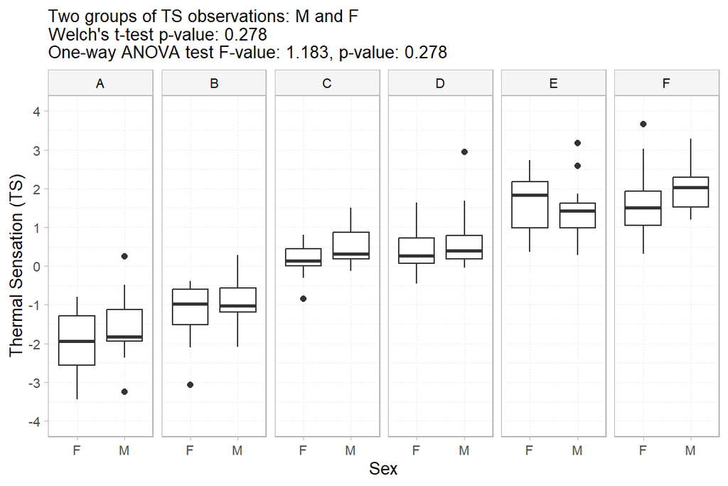

Figure 6: Statistical difference

```r
t = dat |> t_test(TS ~ Sex)

anova = dat |> anova_test(TS ~ Sex)

subtitle = str_c(
   "Two groups of TS observations: M and F\n",
   "Welch's t-test p-value: ",
   signif(t$p, 3), "\n",
   "One-way ANOVA test F-value: ",
   anova$F,
   ", p-value: ",
   anova$p
)

plt_q6 = dat |>
   ggplot(aes(Sex, TS)) +
      geom_boxplot() +
      facet_grid(. ~ Experiment) +
      labs(y = "Thermal Sensation (TS)", subtitle = subtitle) +
      scale_y_continuous(breaks = seq(-4, 4, 1), limits = c(-4, 4))

ggsave("output/q6_differences.png", width = 6, height = 4, units = "in")
plt_q6
```

**Interpretation.** The plot below shows the thermal sensation for each sex (they are grouped by the experiment ID to better visualise the differences; the statistical tests were done for just one categorical group of sex). The ANOVA F-value is close to 1, which means there is low variation between the means of the two groups (which agrees with the boxplot in Figure 2). The p-value for both ANOVA and t-tests is well above 0.05, indicating that the differences between the two groups is not statistically significant.